# HW_6

Aritra

2023-12-05

```r
library(ggplot2)
```

```r
# Load the data
hospital_data <- read.csv("/Users/aritraray/Desktop/week 6 data-1.csv")
```

```r
head(hospital_data)
```

```
##   Expenditures Enrolled       RVUs    FTEs Quality.Score
## 1    114948144    25294  402703.73  954.91          0.67
## 2    116423140    42186  638251.99  949.25          0.58
## 3    119977702    23772  447029.54  952.51          0.52
## 4     19056531     2085   43337.26  199.98          0.93
## 5    246166031    67258 1579789.36 2162.15          0.96
## 6    152125186    23752  673036.55 1359.07          0.56
```

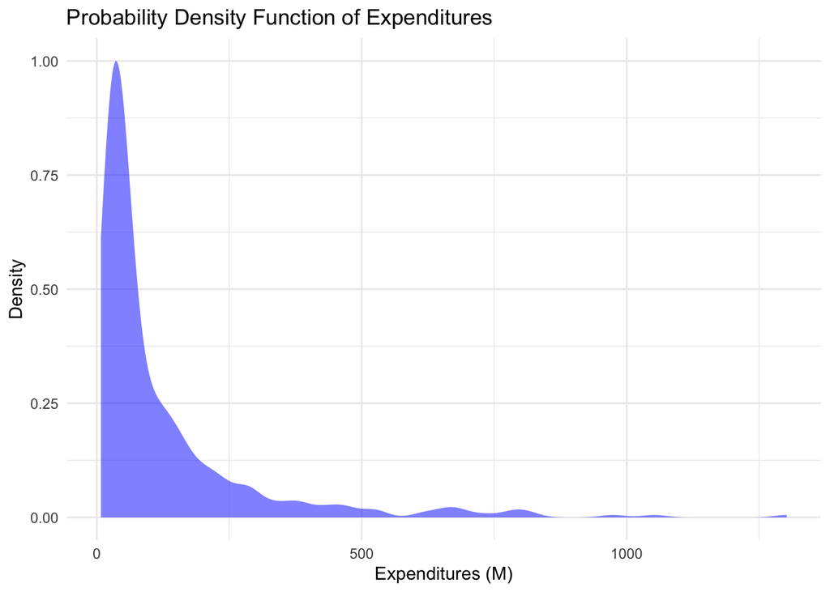

```r
# Convert Expenditures to millions
hospital_data$Expenditures_M <- hospital_data$Expenditures / 1e6

ggplot(hospital_data, aes(x = Expenditures_M)) +
  stat_density(aes(y = after_stat(scaled)), geom = "area", fill = "blue", alpha = 0.5) +
  labs(title = "Probability Density Function of Expenditures", x = "Expenditures (M)", y = "Density") +
  theme_minimal()
```

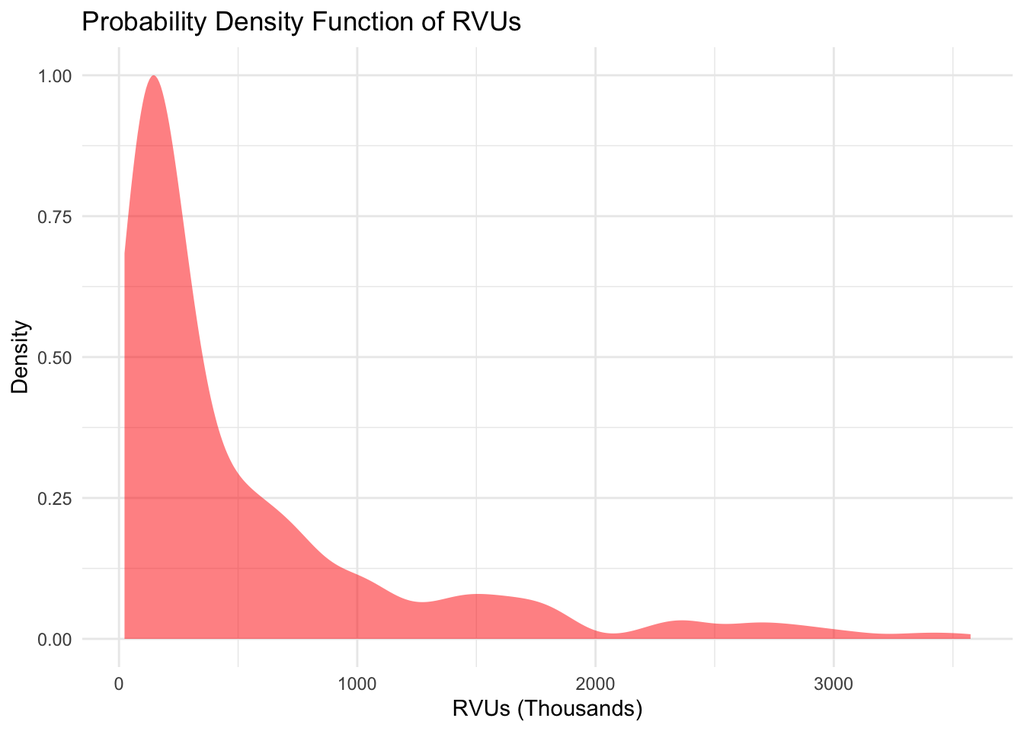

```r
# Convert RVUs to a more readable format
hospital_data$RVUs_readable <- hospital_data$RVUs / 1e3

ggplot(hospital_data, aes(x = RVUs_readable)) +
  stat_density(aes(y = ..scaled..), geom = "area", fill = "red", alpha = 0.5) +
  labs(title = "Probability Density Function of RVUs", x = "RVUs (Thousands)", y = "Density") +
  theme_minimal()
```

```r
# Correlation analysis
correlation <- cor(hospital_data$RVUs, hospital_data$Expenditures)
print(paste("Correlation between RVUs and Expenditure:", correlation))
```

```
## [1] "Correlation between RVUs and Expenditure: 0.921723872910014"
```

The correlation coefficient of approximately 0.92 between RVUs and Expenditure indicates a strong positive linear relationship between these two variables. This suggests that as the standard outpatient workload (RVUs) increases, hospital expenditures also tend to increase.

```r
# Fit linear model
linear_model <- lm(Expenditures ~ RVUs, data = hospital_data)
summary(linear_model)
```

```
##
## Call:
## lm(formula = Expenditures ~ RVUs, data = hospital_data)
##
## Residuals:
##        Min         1Q     Median         3Q        Max
## -185723026  -14097620    2813431   11919781  642218316
##
## Coefficients:
##               Estimate Std. Error t value Pr(>|t|)
## (Intercept) -3.785e+06  4.413e+06  -0.858    0.392
## RVUs         2.351e+02  5.061e+00  46.449   <2e-16 ***
## ---
## Signif. codes:  0 '***' 0.001 '**' 0.01 '*' 0.05 '.' 0.1 ' ' 1
##
## Residual standard error: 67350000 on 382 degrees of freedom
## Multiple R-squared:  0.8496, Adjusted R-squared:  0.8492
## F-statistic:  2157 on 1 and 382 DF,  p-value: < 2.2e-16
```

**Interpretation of Coefficients:**

1. **Intercept (β₀):** The intercept is -3.785e+06. It represents the estimated Expenditure when RVUs are zero. However, in this context, the interpretation might not be meaningful as RVUs are unlikely to be zero.
2. **RVUs (β₁):** The coefficient for RVUs is 2.351e+02. It represents the estimated change in Expenditure for a one-unit increase in RVUs. The p-value (<2e-16) suggests that this coefficient is statistically significant.

**Model Performance:**

- **R-squared:** The R-squared value of 0.8496 indicates that approximately 85% of the variability in Expenditure can be explained by the linear relationship with RVUs.